# QMSS4058 Final Project

## Tree Models

Tree methods divide the predictor space into non-overlapping regions, and when considering each split, attempts to minimize residual sum of squares for regression problems, and minimize classification error rate or gini index (node purity) for classification problems.

Trees are inherently capable of effectively handling complicated data sets and are interactive in nature. They are computationally efficient and particularly effective when your number of predicors is greater than the number of observations.

We start with a simple tree.

```r
library(tree)
treemod <- tree(left ~ ., data = training)
yhat_tree <- predict(treemod, newdata = testing, type = "class")
table_tree <- table(testing$left, yhat_tree)
sum(diag(table_tree)) / sum(table_tree)
```

```
## [1] 0.9336769
```

A single tree has gives a very high prediction accuracy rate.

The idea of tree pruning is to grow a large tree and ‘prune’ it, to get the subtree with the lowest test error rate. Pruning overcomes the problem of overfitting in simple trees.

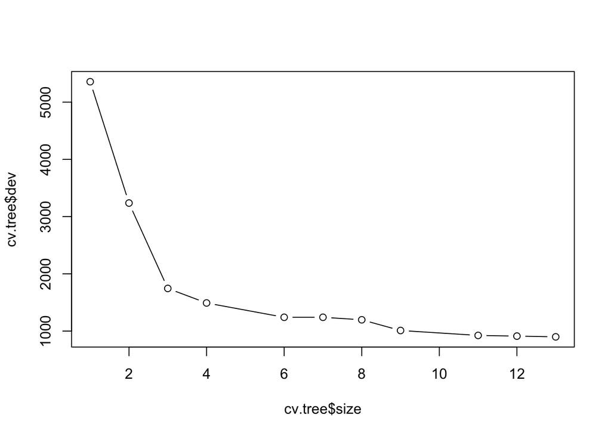

```r
cv.tree <- cv.tree(treemod, FUN = prune.misclass)
plot(cv.tree$size, cv.tree$dev, type = 'b')
```

```r
prune.tree <- prune.tree(treemod, best = 8)
y_hat_treep <- predict(prune.tree, newdata = testing, type = "class")
table_treep <- table(testing$left, y_hat_treep)
sum(diag(table_treep)) / sum(table_treep)
```

```
## [1] 0.909702
```

The pruned tree has a slightly lower prediction rate but is more parsimonious.

Next, we tried bagging. Bagging is a method that utilizes a bootstrap sampling method, which involves creating multiple samples of the original training data to fit the model. Bagging averages the resulting trees to create a single predictive tree model. We used randomForest() and specified that it uses all predictor variables through “mtry =”.

```r
library(randomForest)
bag <- randomForest(left ~ ., data = training, important = T,
                    mtry = ncol(training) - 1)
importance(bag)
```

```
##                 MeanDecreaseGini
## satislevel            2405.63077
## lasteval               654.54992
## projectnumber          279.59983
## ave_month_hours        419.57365
## time_w_comp           2332.23067
## work_accid              19.89585
## promo_5years           158.44004
## dept                   136.00119
## salary                  19.45200
```

In relation to the gini index (node purity), satislevel is deemed the most important variable in making the node pure.

```r
yhat_bag <- predict(bag, testing, type = "class")
table_bag <- table(testing$left, yhat_bag)
sum(diag(table_bag)) / sum(table_bag)
```

```
## [1] 0.9838674
```

A bagged model significantly increases the accuracy rate.

Now we try random forest, which decorrelates the trees by forcing it to consider only a subset of variables when performing a split. Similar to bagging, random forest uses the bootstrapping sampling method, but before making a split in a tree it considers a subset of m predictors, as split candidates, from the total of p predictors, where m = root p.

```r
library(randomForest)
rffit <- train(training[, -7], training[, 7], method = "rf",
               trControl = ctrl)
rffit$bestTune
```

```
##   mtry
## 1    2
```

```r
rfmod <- randomForest(left ~ ., data = training, important = T,
                   ntree = 500, mtry = 2)
yhat_rf <- predict(rfmod, testing, type = "class")
table_rf <- table(testing$left, yhat_rf)
sum(diag(table_rf)) / sum(table_rf)
```

```
## [1] 0.9840914
```

Prediction accuracy with random forest is higher than the bagged model. This is expected as random forest is superior at capturing high order interactions and is robust to outliers.

Next we try boosting. Boosting is a tree-based iterative learning method, where each tree is grown using information from previously grown trees. Specifically, the next iteration gives more weight to data points that were poorly predicted in the previous model; the next model is refined to better predict those data points. Hence boosting learns slowly, as opposed to a large single decision tree which could result in overfitting.

```r
library(gbm)
n.cores = parallel::detectCores()
boostfit <- train(training[, -7], training$left,
                  method = "gbm", metric = "ROC", trControl = ctrl)
boostfit$bestTune
```

```
##   n.trees interaction.depth shrinkage n.minobsinnode
## 9     150                 3       0.1             10
```

```r
boost.mod <- gbm(left == "Yes" ~ ., data = training,
                   distribution = "bernoulli", n.trees = 50,
                   interaction.depth = 1, shrinkage = 0.1, n.minobsinnode = 10,
                   verbose = F)
yhat.boost <- predict(boost.mod, newdata = testing, type = "response", n.trees = 50)
zhat.boost <- as.integer(yhat.boost > 0.5)
tableboost <- table(testing$left, zhat.boost)
sum(diag(tableboost)) / sum(tableboost)
```

```
## [1] 0.8928972
```

Boosting performs worse than the single tree model, which is a bit surprising.

Next we tried bartMachine, which uses Bayesian probability to make more sound predictions rather than relying on a rote and repetitive algorithm prediction process.

```r
options(java.parameters = "-Xmx5g")
library(rJava)
library(bartMachine)
set_bart_machine_num_cores(parallel::detectCores())
```

```
## bartMachine now using 4 cores.
```

```r
bartfit <- train(training[, -7], training[, 7], method = "bartMachine",
                 metric = "ROC", trControl = ctrl)
```

[output not shown]

[output cut: 845 more lines]

[output not shown]

[output not shown]

```r
bartfit$bestTune
```

```
##   num_trees  k alpha beta nu
## 3        50 NA   0.9    3 NA
```

```r
bMmodel <- bartMachine(training[, -7], y = training$left, num_trees = 50,
                    alpha = 0.99, beta = 3)
```

```
## bartMachine initializing with 50 trees...
## bartMachine vars checked...
## bartMachine java init...
## bartMachine factors created...
## bartMachine before preprocess...
## bartMachine after preprocess... 22 total features...
## bartMachine sigsq estimated...
## bartMachine training data finalized...
## Now building bartMachine for classification ...Covariate importance prior ON.
## evaluating in sample data...done
```

```r
yhat_bart <- predict(bMmodel, new_data = testing[, -7], type = "class")
table_bart <- table(testing$left, yhat_bart)
sum(diag(table_bart)) / sum(table_bart)
```

```
## [1] 0.9681828
```

## Neural Networks

Next, we try neural networks. Neural networks closely mimic the workings of a human brain to connect predictors and the response. Neural networks perform linear combinations of the original predictors, which are then transformed by a nonlinear function to produce hidden units. Unlike other dimension reduction methods such as Partial Least Squares, there are no constraints that help define these linear combinations. We first performed a correlation test to see if there are highly correlated variables we should remove.

```r
tooHigh <- findCorrelation(cor(training[, c(1:6)]), cutoff = .75)
```

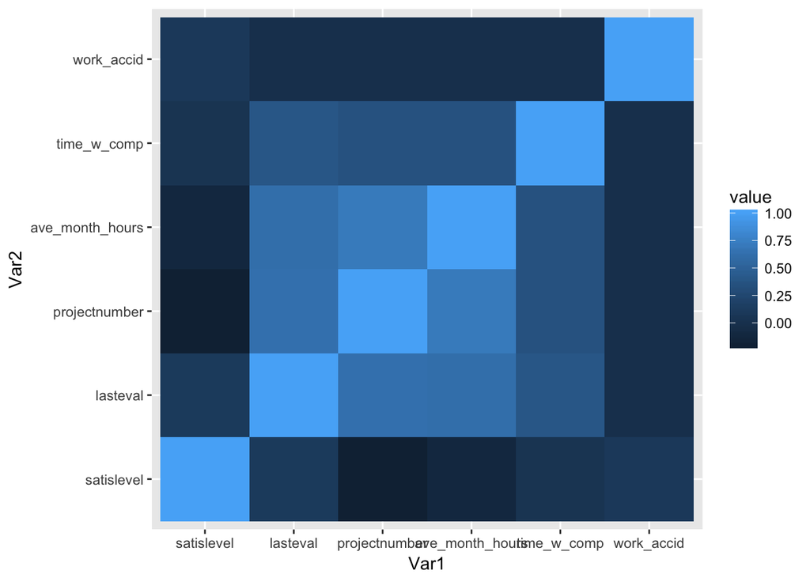

```r
library(ggplot2)
library(reshape2)
qplot(x = Var1, y = Var2, data = melt(cor(training[, c(1:6)])), fill = value, geom = "tile")
```

The heatmap demonstrates that there is little correlation between the predictors. Thus, we use the full predictor set. Now we perform averaging neural network, which aggregates multiple neural network models for better prediction.

```r
library(nnet)
nnetfit <- train(training[, -7], training[, 7], method = "avNNet",
                 trControl = ctrl)
```

[output not shown]

[output cut: 855 more lines]

[output not shown]

```r
nnetfit$bestTune
```

```
##   size decay   bag
## 9    5   0.1 FALSE
```

```r
nnetAvg <- avNNet(left ~ ., data = training, size = 5, decay = 0.1,
                  lineout = T, trace = F)
yhat_nnet <- predict(nnetAvg, testing[, -7])
zhat_nnet <- as.integer(yhat_nnet[, 2] > 0.5)
table_nnet <- table(testing$left, zhat_nnet)
sum(diag(table_nnet)) / sum(table_nnet)
```

```
## [1] 0.9442079
```

The neural network model has a high prediction accuracy rate.

The model with the highest accuracy rate is random Forest, and other tree-based models have proved highly predictive as well. As mentioned before, it may be because the variables are non-linear and potentially interactive.